# Examen Mod 1

Natalia Blanco

2023-05-11

# Parte 1

## Preguntas

**1. Describir autocorrelación espacial, autocorrelación espacial positiva, y autocorrelación espacial negativa.**

- La autocorrelación espacial determina la presencia de variación espacial en una variable.
- Cuando hay presencia de autocorrelación espacial positiva significa que los espacios cercanos tienen valores similares se puede visualizar con la presencia de clusters en un mapa.
- Cuando hay correlación espacial negativa significa que los espacios cercanos tienen valores diferentes entre sí, un ejemplo seria si en un vecindario hay casa de diferentes precios unos siendo muy altos y unos muy bajos.

**2. Describir al menos 3-5 diferencias entre análisis exploratorio de datos (EDA) y análisis exploratorio espacial de datos (ESDA).**

- En el EDA análisis exploratorio de datos se analizan y se busca encontrar patrones entre las variables de una serie de datos por medio de la elaboración de gráficos, correologramas, visualizaciones etc.
- En el ESDA se busca encontrar patrones y/o relaciones en una serie de datos espaciales por medio de la elaboración de mapas.
- Para elaborar el ESDA es necesario tener datos espaciales ya que se utilizan ubicaciones y atributos geográficos.

**3. Describir los conceptos de autocorrelación espacial y no estacionariedad en un contexto de análisis espacial de datos.**

- La autocorrelación espacial determina la variación espacial o la ausencia de esta entre los espacios cercanos en una variable, es importante determinar la presencia o ausencia de autocorrelación espacial en un análisis espacial de datos ya que permiten un mejor entendimiento del comportamiento de los datos, así mismo nos ayuda a identificar si es necesario a ver un cambio en las variables.
- La no estacionariedad se presenta cuando propiedades en una variable o base de datos cambian con el tiempo y no son consistentes a lo largo de un periodo de tiempo. En un contexto espacial de datos la no estacionariedad se presenta cuando existen valores extremos en un área esto puede ser valores muy bajos y muy altos. Un ejemplo de esto podría ser la pobreza en México ya que esta es muy alta en unas regiones y muy baja en otras a lo largo del país.

**4. Describir al menos 3-5 diferencias entre GWR y GRF.**

- GFR utiliza una versión local de machine learning para determinar la existencia de no estacionariedad espacial.
- GRF modela la no estacionariedad junto con un modelo no lineal flexible.
- El GRF es difícil de overfit debido a sus técnicas de bootstrapping
- El propósito de GRF es servir como una conexión entre el machine learning y los modelos geográficos ya que combina la capacidad de hacer inferencias y brindar explicaciones.

**5. Describir al menos 3-5 diferencias entre la estimación de modelo de regresión no espacial, espacial global, y espacial local.**

- El modelo de regresión no espacial no utiliza datos espaciales y se puede conducir con una base de datos regular.
- El modelo espacial local ajusta una ecuación de regresión a cada característica presente en el conjunto de datos lo que le permite obtener resultados locales.
- El modelo espacial global no diferencia entre las diferentes regiones.

**Referencias**

Abdishakur. (2019, November 5). What is Exploratory Spatial Data Analysis (ESDA)?. Medium. https://towardsdatascience.com/what-is-exploratory-spatial-data-analysis-esda-335da79026ee

Geographically weighted Random Forest. R Documentation. (n.d.). https://search.r-project.org/CRAN/refmans/SpatialML/html/grf.html

Geographically weighted regression (GWR) (spatial statistics). Geographically Weighted Regression (GWR) (Spatial Statistics)-ArcGIS Pro | Documentation. (n.d.). https://pro.arcgis.com/en/pro-app/latest/tool-reference/spatial-statistics/geographicallyweightedregression.htm

Kanade, V. A. (2022, August 17). What is spatial analysis? definition and examples. Spiceworks. https://www.spiceworks.com/tech/artificial-intelligence/articles/what-is-spatial-analysis/

Regression Analysis Basics. Regression analysis basics-ArcGIS Pro | Documentation. (n.d.). https://pro.arcgis.com/en/pro-app/latest/tool-reference/spatial-statistics/regression-analysis-basics.htm#:~:text=Regression%20analysis%20allows%20you%20to,factors%20behind%20observed%20spatial%20patterns

What is exploratory data analysis?. IBM. (n.d.). https://www.ibm.com/topics/exploratory-data-analysis

Presentación (MODULE 1: SPATIAL DATA ANALYSIS)

# Parte 2

```r
library(sf)
library(dplyr)
library(tmap)
library(spdep)
library(rgdal)
library(tidyverse)
library(tigris)
library(mapview)
library(GWmodel)
library(regclass)
library(viridis)
library(grid)
library(RColorBrewer)
library(rgeoda)
library(sjPlot)
library(jtools)
library(dlookr)
library(terra)
library(ggpubr)
library(rstatix)
library(maptools)
library(SpatialML)
library(spgwr)
library(grid)
```

**Importar los datos**

```r
###
data(columbus) ### dataset
columbus_shp <- readShapePoly(system.file("etc/shapes/columbus.shp",package="spdep"))
### shapefile
col.gal.nb <- read.gal(system.file("etc/weights/columbus.gal", package="spdep"))
### spatial connectivity matrix but it requires to calculate the spatial weights.
##
```

**Limpieza de datos**

```r
summary(col.gal.nb)
```

```
## Neighbour list object:
## Number of regions: 49
## Number of nonzero links: 230
## Percentage nonzero weights: 9.579342
## Average number of links: 4.693878
## Link number distribution:
##
##  2  3  4  5  6  7  8  9 10
##  7  7 13  4  9  6  1  1  1
## 7 least connected regions:
## 1 6 31 39 42 46 47 with 2 links
## 1 most connected region:
## 20 with 10 links
```

```r
summary(columbus)
```

```
##       AREA           PERIMETER        COLUMBUS.    COLUMBUS.I     POLYID
##  Min.   :0.03438   Min.   :0.9021   Min.   : 2   Min.   : 1   Min.   : 1
##  1st Qu.:0.09315   1st Qu.:1.4023   1st Qu.:14   1st Qu.:13   1st Qu.:13
##  Median :0.17477   Median :1.8410   Median :26   Median :25   Median :25
##  Mean   :0.18649   Mean   :1.8887   Mean   :26   Mean   :25   Mean   :25
##  3rd Qu.:0.24669   3rd Qu.:2.1992   3rd Qu.:38   3rd Qu.:37   3rd Qu.:37
##  Max.   :0.69926   Max.   :5.0775   Max.   :50   Max.   :49   Max.   :49
##       NEIG        HOVAL            INC             CRIME
##  Min.   : 1   Min.   :17.90   Min.   : 4.477   Min.   : 0.1783
##  1st Qu.:13   1st Qu.:25.70   1st Qu.: 9.963   1st Qu.:20.0485
##  Median :25   Median :33.50   Median :13.380   Median :34.0008
##  Mean   :25   Mean   :38.44   Mean   :14.375   Mean   :35.1288
##  3rd Qu.:37   3rd Qu.:43.30   3rd Qu.:18.324   3rd Qu.:48.5855
##  Max.   :49   Max.   :96.40   Max.   :31.070   Max.   :68.8920
##       OPEN             PLUMB             DISCBD            X
##  Min.   : 0.0000   Min.   : 0.1327   Min.   :0.370   Min.   :24.25
##  1st Qu.: 0.2598   1st Qu.: 0.3323   1st Qu.:1.700   1st Qu.:36.15
##  Median : 1.0061   Median : 1.0239   Median :2.670   Median :39.61
##  Mean   : 2.7709   Mean   : 2.3639   Mean   :2.852   Mean   :39.46
##  3rd Qu.: 3.9364   3rd Qu.: 2.5343   3rd Qu.:3.890   3rd Qu.:43.44
##  Max.   :24.9981   Max.   :18.8111   Max.   :5.570   Max.   :51.24
##        Y              AREA             NSA              NSB
##  Min.   :24.96   Min.   : 1.093   Min.   :0.0000   Min.   :0.0000
##  1st Qu.:28.26   1st Qu.: 3.193   1st Qu.:0.0000   1st Qu.:0.0000
##  Median :31.91   Median : 6.029   Median :0.0000   Median :1.0000
##  Mean   :32.37   Mean   : 6.372   Mean   :0.4898   Mean   :0.5102
##  3rd Qu.:35.92   3rd Qu.: 7.989   3rd Qu.:1.0000   3rd Qu.:1.0000
##  Max.   :44.07   Max.   :21.282   Max.   :1.0000   Max.   :1.0000
##        EW               CP             THOUS          NEIGNO
##  Min.   :0.0000   Min.   :0.0000   Min.   :1000   Min.   :1001
##  1st Qu.:0.0000   1st Qu.:0.0000   1st Qu.:1000   1st Qu.:1013
##  Median :1.0000   Median :0.0000   Median :1000   Median :1025
##  Mean   :0.5918   Mean   :0.4898   Mean   :1000   Mean   :1025
##  3rd Qu.:1.0000   3rd Qu.:1.0000   3rd Qu.:1000   3rd Qu.:1037
##  Max.   :1.0000   Max.   :1.0000   Max.   :1000   Max.   :1049
##      PERIM
##  Min.   :0.9021
##  1st Qu.:1.4023
##  Median :1.8410
##  Mean   :1.8887
##  3rd Qu.:2.1992
##  Max.   :5.0775
```

Cambiar nombre de la variable que se repite.

```r
colnames(columbus)[1] <- "Area"
```

Cambiar 0 a 0.0001

```r
columbus$OPEN <- replace(columbus$OPEN, columbus$OPEN == 0, 0.0001)
```

```r
summary(columbus_shp)
```

```
## Object of class SpatialPolygonsDataFrame
## Coordinates:
##         min      max
## x  5.874907 11.28742
## y 10.788630 14.74245
## Is projected: NA
## proj4string : [NA]
## Data attributes:
##       AREA           PERIMETER        COLUMBUS_    COLUMBUS_I     POLYID
##  Min.   :0.03438   Min.   :0.9021   Min.   : 2   Min.   : 1   Min.   : 1
##  1st Qu.:0.09315   1st Qu.:1.4023   1st Qu.:14   1st Qu.:13   1st Qu.:13
##  Median :0.17477   Median :1.8410   Median :26   Median :25   Median :25
##  Mean   :0.18649   Mean   :1.8887   Mean   :26   Mean   :25   Mean   :25
##  3rd Qu.:0.24669   3rd Qu.:2.1992   3rd Qu.:38   3rd Qu.:37   3rd Qu.:37
##  Max.   :0.69926   Max.   :5.0775   Max.   :50   Max.   :49   Max.   :49
##       NEIG        HOVAL            INC             CRIME
##  Min.   : 1   Min.   :17.90   Min.   : 4.477   Min.   : 0.1783
##  1st Qu.:13   1st Qu.:25.70   1st Qu.: 9.963   1st Qu.:20.0485
##  Median :25   Median :33.50   Median :13.380   Median :34.0008
##  Mean   :25   Mean   :38.44   Mean   :14.375   Mean   :35.1288
##  3rd Qu.:37   3rd Qu.:43.30   3rd Qu.:18.324   3rd Qu.:48.5855
##  Max.   :49   Max.   :96.40   Max.   :31.070   Max.   :68.8920
##       OPEN             PLUMB             DISCBD            X
##  Min.   : 0.0000   Min.   : 0.1327   Min.   :0.370   Min.   :24.25
##  1st Qu.: 0.2598   1st Qu.: 0.3323   1st Qu.:1.700   1st Qu.:36.15
##  Median : 1.0061   Median : 1.0239   Median :2.670   Median :39.61
##  Mean   : 2.7709   Mean   : 2.3639   Mean   :2.852   Mean   :39.46
##  3rd Qu.: 3.9364   3rd Qu.: 2.5343   3rd Qu.:3.890   3rd Qu.:43.44
##  Max.   :24.9981   Max.   :18.8111   Max.   :5.570   Max.   :51.24
##        Y              NSA              NSB               EW
##  Min.   :24.96   Min.   :0.0000   Min.   :0.0000   Min.   :0.0000
##  1st Qu.:28.26   1st Qu.:0.0000   1st Qu.:0.0000   1st Qu.:0.0000
##  Median :31.91   Median :0.0000   Median :1.0000   Median :1.0000
##  Mean   :32.37   Mean   :0.4898   Mean   :0.5102   Mean   :0.5918
##  3rd Qu.:35.92   3rd Qu.:1.0000   3rd Qu.:1.0000   3rd Qu.:1.0000
##  Max.   :44.07   Max.   :1.0000   Max.   :1.0000   Max.   :1.0000
##        CP             THOUS          NEIGNO
##  Min.   :0.0000   Min.   :1000   Min.   :1001
##  1st Qu.:0.0000   1st Qu.:1000   1st Qu.:1013
##  Median :0.0000   Median :1000   Median :1025
##  Mean   :0.4898   Mean   :1000   Mean   :1025
##  3rd Qu.:1.0000   3rd Qu.:1000   3rd Qu.:1037
##  Max.   :1.0000   Max.   :1000   Max.   :1049
```

Cambiar 0 a 0.0001

```r
columbus_shp$OPEN <- replace(columbus_shp$OPEN, columbus_shp$OPEN == 0, 0.0001)
```

# Análisis Exploratorio de Datos (EDA)

Crear un data set con las variables que se usaran en el corplot

```r
corp <- columbus %>% select(AREA,PERIMETER, NEIG, HOVAL, INC, CRIME, OPEN, PLUMB, PLUMB, DISCBD,
                            NSA, NSB, EW, CP, NEIGNO)
```

**Corplot**

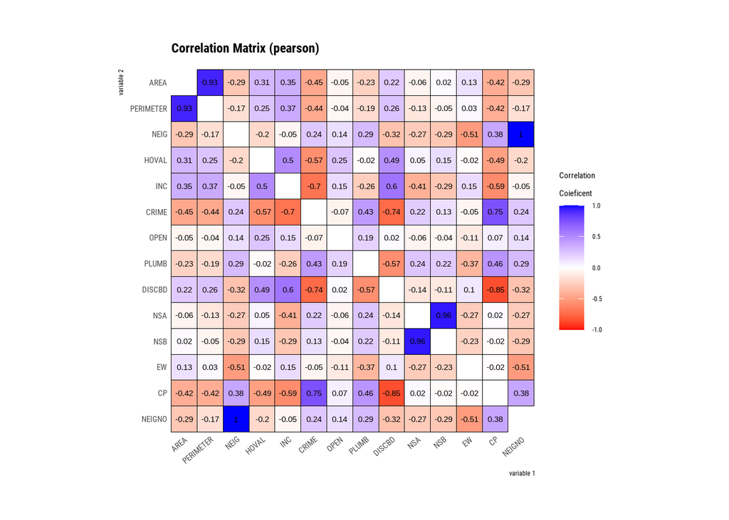

```r
correlate(corp, AREA,PERIMETER, NEIG, HOVAL, INC, CRIME, OPEN, PLUMB, PLUMB, DISCBD,
                            NSA, NSB, EW, CP, NEIGNO) %>% plot()
```

En base al corplot las variables que elegí para conducir el análisis debido a la correlación que estas tienen con la variable dependiente (HOVAL) son las siguientes:

- HOVAL (variable dependiente): Valor de la vivienda (en $1,000) USD
- DISCBD: Distancia al business district.
- CRIME: Robos residenciales y robos de vehículos por cada mil hogares en el vecindario.
- INC: Ingresos del hogar (en $1,000)
- AREA: El área del vecindario en millas cuadradas

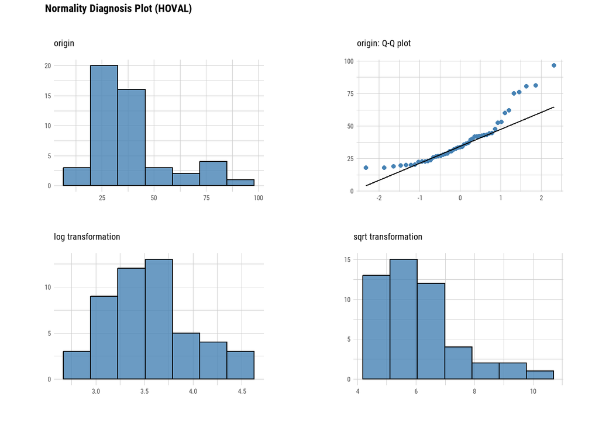

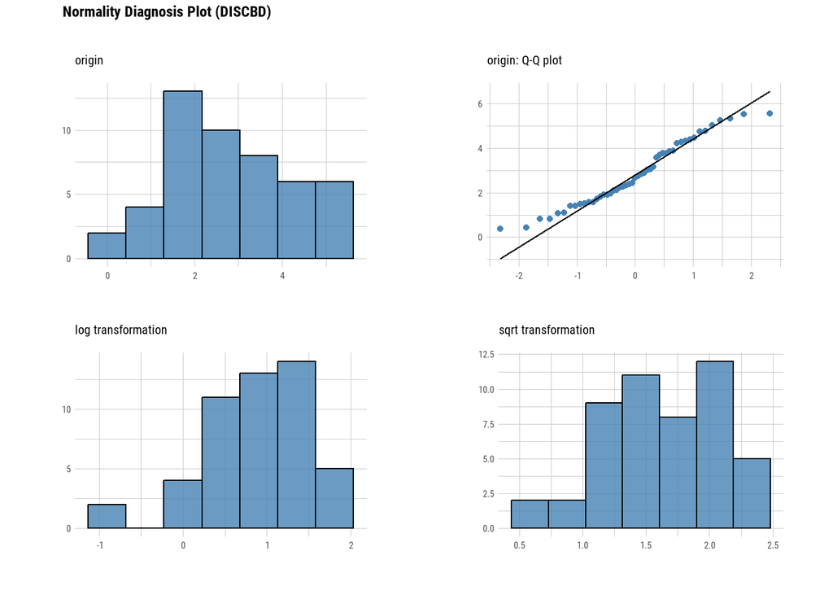

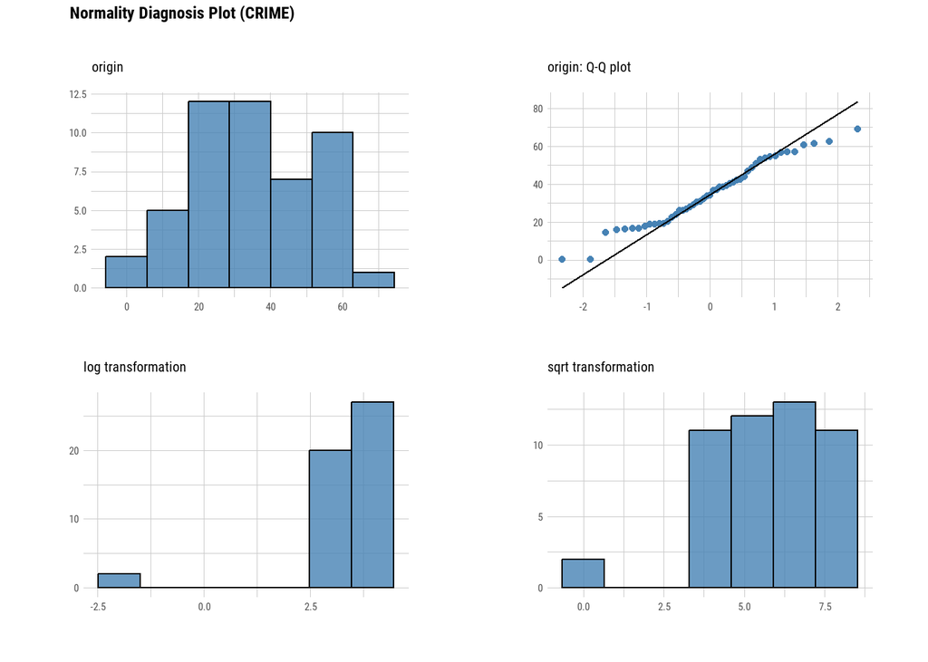

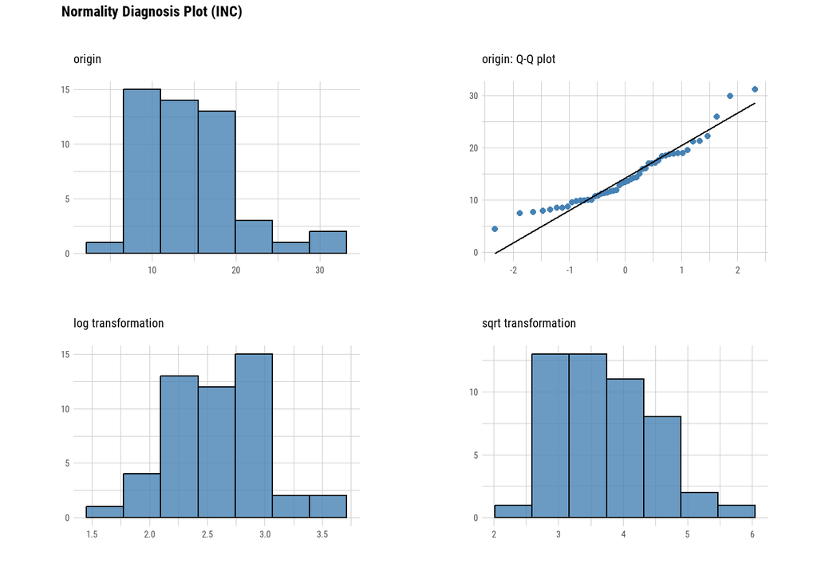

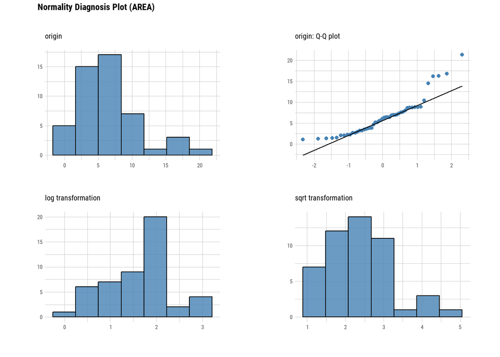

```r
plot_normality(columbus, HOVAL, DISCBD, CRIME, INC, AREA)
```

- En base a las transformaciones que podemos visualizar en el plot_normality estaré transformando a log la variable dependiente (HOVAL) así como la variable INC ya que al convertirlas a log tienen una mejor distribución.

# Análisis Exploratorio Espacial de los Datos (ESDA)

## Identificar autocorrelación espacial global

**Queen approach**

```r
swm_qn <- poly2nb(columbus_shp, queen = TRUE)
```

**Queen contiguity based neighbors map**

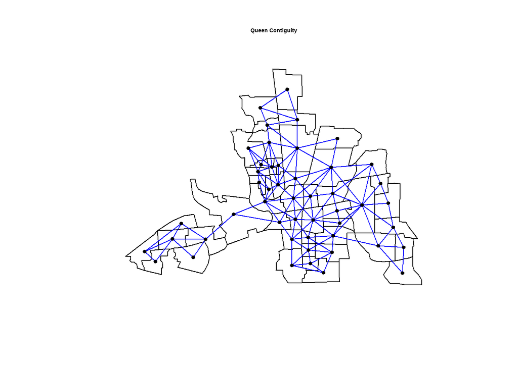

```r
plot(columbus_shp, borders = 'lightgrey')
plot(swm_qn, coordinates(columbus_shp), pch = 19, cex = 0.6, add = TRUE, col = "blue")
title(main = "Queen Contiguity", cex.main = 0.9)
```

**rook approach**

```r
swm_r <- poly2nb(columbus_shp, queen = FALSE)
```

**rook contiguity based neighbors map**

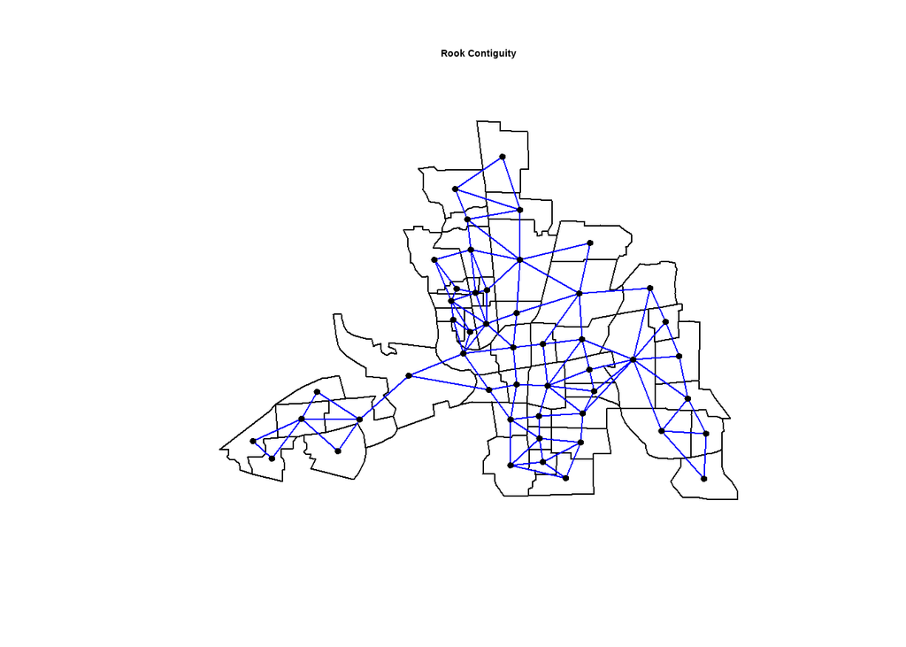

```r
plot(columbus_shp, borders = 'lightgrey')
plot(swm_r, coordinates(columbus_shp), pch = 19, cex = 0.6, add = TRUE, col = "blue")
title(main = "Rook Contiguity", cex.main = 0.9)
```

- Estandaricemos las matrices de conectividad espacial queen y rook (W significa ponderado) para poder asignar mayor importancia (peso) a los vecinos más cercanos que a los vecinos distantes.

```r
rswm_qn <- nb2listw(swm_qn, style = "W", zero.policy = TRUE)
rswm_r  <- nb2listw(swm_r, style = "W", zero.policy = TRUE)
```

**Global Moran’s I Test**

HOVAL

```r
moran.test(columbus_shp$HOVAL, listw = rswm_qn, zero.policy = TRUE, na.action = na.omit)
```

```
##
##  Moran I test under randomisation
##
## data:  columbus_shp$HOVAL
## weights: rswm_qn
##
## Moran I statistic standard deviate = 2.2071, p-value = 0.01365
## alternative hypothesis: greater
## sample estimates:
## Moran I statistic       Expectation          Variance
##       0.180093114      -0.020833333       0.008287783
```

- En base a los resultados podemos concluir que hay autocorrelación espacial positiva.

DISCBD

```r
moran.test(columbus_shp$DISCBD, listw = rswm_qn, zero.policy = TRUE, na.action = na.omit)
```

```
##
##  Moran I test under randomisation
##
## data:  columbus_shp$DISCBD
## weights: rswm_qn
##
## Moran I statistic standard deviate = 8.7904, p-value < 2.2e-16
## alternative hypothesis: greater
## sample estimates:
## Moran I statistic       Expectation          Variance
##       0.800562617      -0.020833333       0.008731396
```

- Autocorrelación espacial positiva
- El resultado del Moran I statistic indica una correlación positiva significativa hacia las observaciones cercanas.

CRIME

```r
moran.test(columbus_shp$CRIME, listw = rswm_qn, zero.policy = TRUE, na.action = na.omit)
```

```
##
##  Moran I test under randomisation
##
## data:  columbus_shp$CRIME
## weights: rswm_qn
##
## Moran I statistic standard deviate = 5.5894, p-value = 1.139e-08
## alternative hypothesis: greater
## sample estimates:
## Moran I statistic       Expectation          Variance
##       0.500188557      -0.020833333       0.008689289
```

- Autocorrelación espacial positiva

INC

```r
moran.test(columbus_shp$INC, listw = rswm_qn, zero.policy = TRUE, na.action = na.omit)
```

```
##
##  Moran I test under randomisation
##
## data:  columbus_shp$INC
## weights: rswm_qn
##
## Moran I statistic standard deviate = 4.7645, p-value = 9.467e-07
## alternative hypothesis: greater
## sample estimates:
## Moran I statistic       Expectation          Variance
##       0.415628778      -0.020833333       0.008391926
```

- Autocorrelación espacial positiva

AREA

```r
moran.test(columbus_shp$AREA, listw = rswm_qn, zero.policy = TRUE, na.action = na.omit)
```

```
##
##  Moran I test under randomisation
##
## data:  columbus_shp$AREA
## weights: rswm_qn
##
## Moran I statistic standard deviate = 1.7634, p-value = 0.03892
## alternative hypothesis: greater
## sample estimates:
## Moran I statistic       Expectation          Variance
##       0.135232758      -0.020833333       0.007833009
```

- Autocorrelación espacial positiva

**Identificar autocorrelación espacial local**

Crear un spatial lag de las variables de interes.

```r
columbus_shp$sp_AREA <- lag.listw(rswm_qn, columbus_shp$AREA, zero.policy = TRUE)
```

```r
columbus_shp$sp_INC <- lag.listw(rswm_qn, columbus_shp$INC , zero.policy = TRUE)
```

```r
columbus_shp$sp_CRIME <- lag.listw(rswm_qn, columbus_shp$CRIME , zero.policy = TRUE)
```

```r
columbus_shp$sp_DISCBD <- lag.listw(rswm_qn, columbus_shp$DISCBD , zero.policy = TRUE)
```

```r
columbus_shp$sp_HOVAL <- lag.listw(rswm_qn, columbus_shp$HOVAL , zero.policy = TRUE)
```

**Clusters**

**HOVAL**

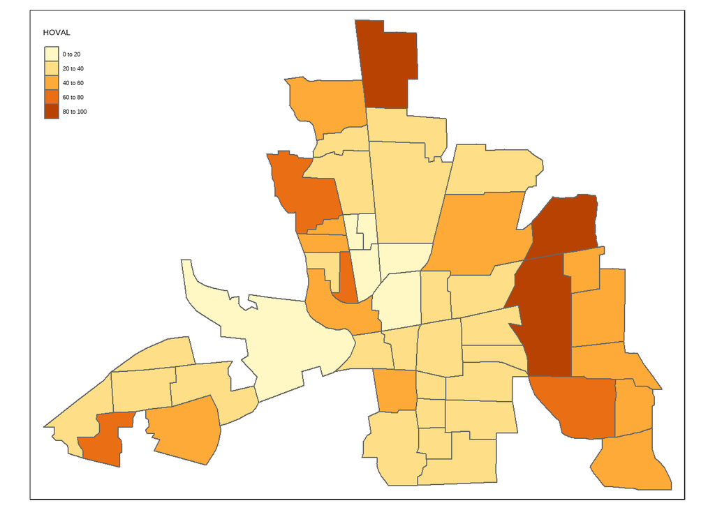

```r
qtm(columbus_shp, "HOVAL")
```

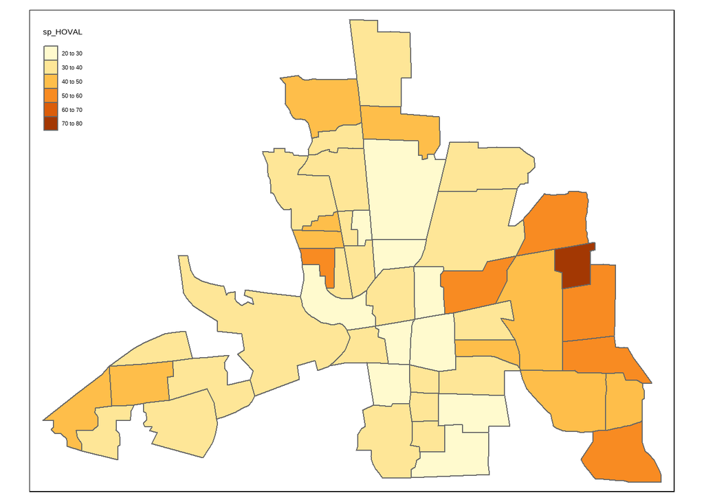

```r
qtm(columbus_shp, "sp_HOVAL")
```

- Se pueden notar clusters en el mapa indicando lo que indica autocorrelación espacial positiva

**AREA**

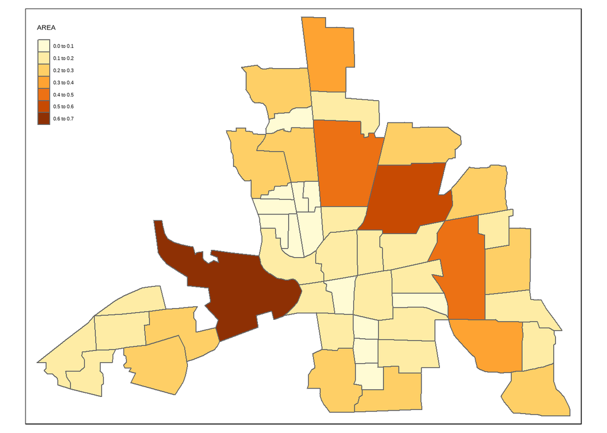

```r
qtm(columbus_shp, "AREA")
```

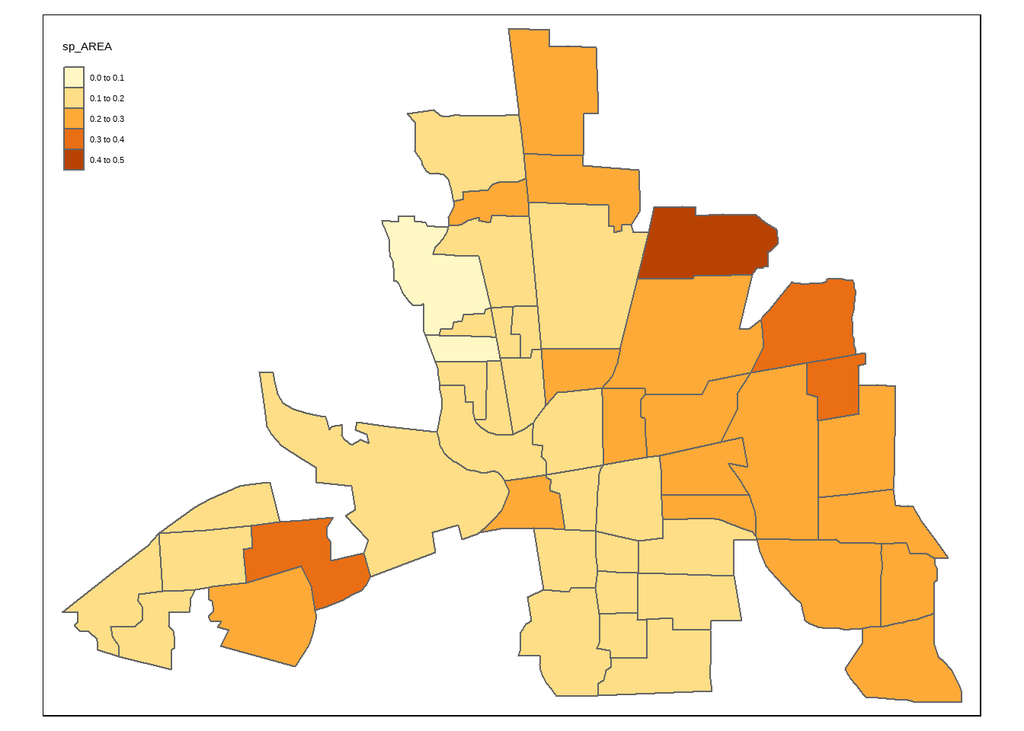

```r
qtm(columbus_shp, "sp_AREA")
```

- En comparación con el mapa normal podemos notar un cluster de valores altos al norte y otro al este de Columbus.
- Existe presencia de autocorrelación espacial positiva

**INC**

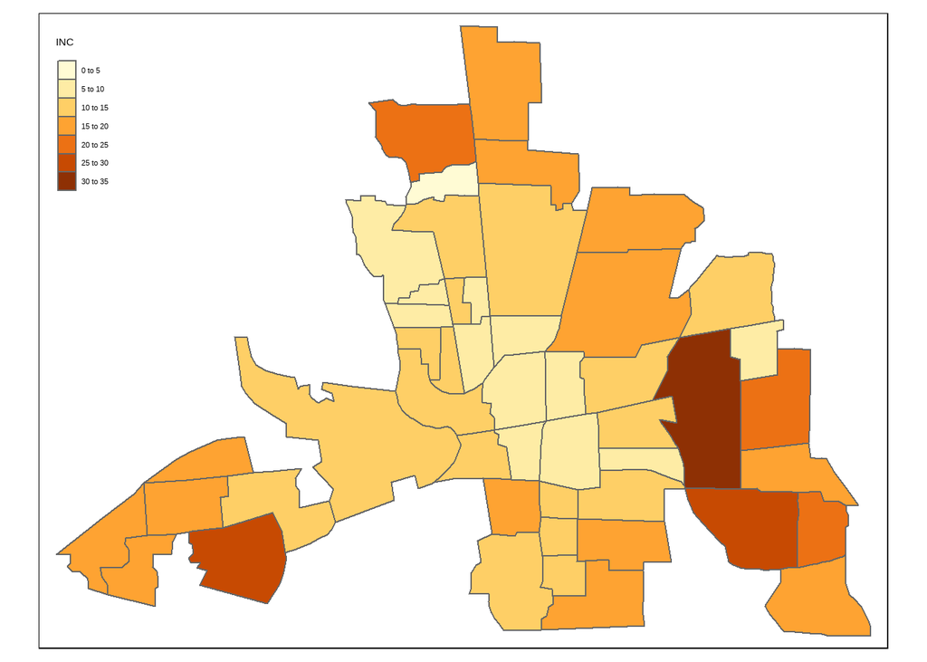

```r
qtm(columbus_shp, "INC")
```

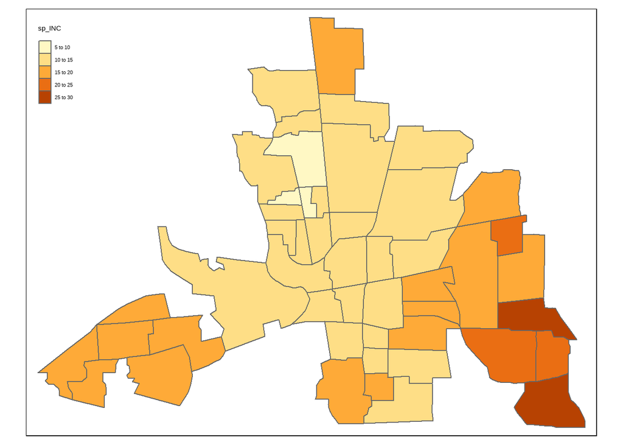

```r
qtm(columbus_shp, "sp_INC")
```

- Podemos notar clusters de valores altos en las áreas del sur, sureste y oeste de Columbus.
- Existe presencia de autocorrelación espacial positiva

**CRIME**

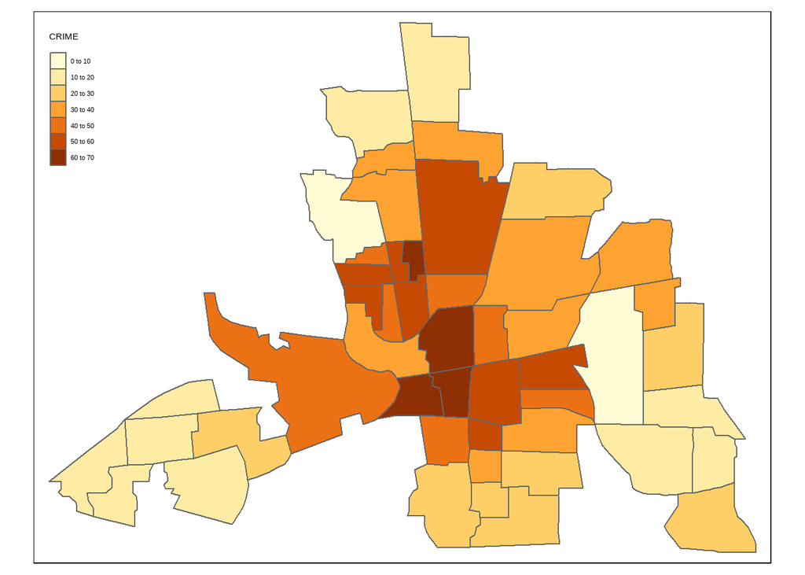

```r
qtm(columbus_shp, "CRIME")
```

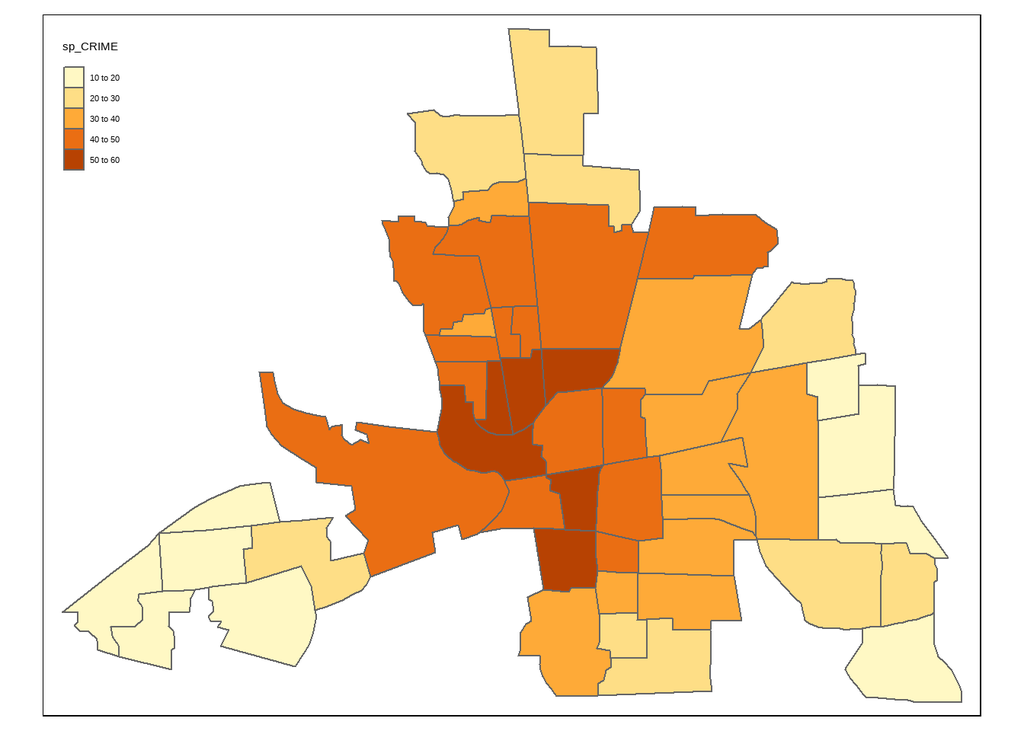

```r
qtm(columbus_shp, "sp_CRIME")
```

- Podemos notar una alta concentración de crimen en el centro y sur de Columbus.
- Existe presencia de autocorrelación espacial positiva

**DISCBD**

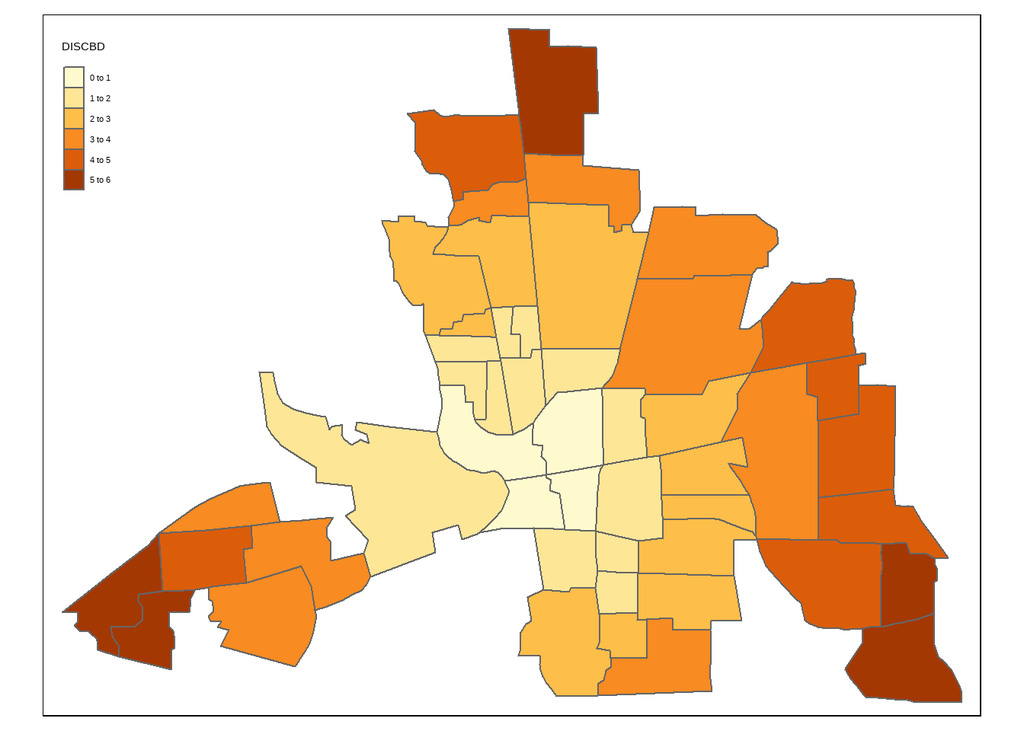

```r
qtm(columbus_shp, "DISCBD")
```

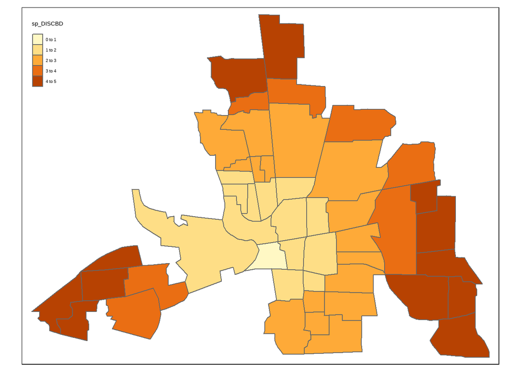

```r
qtm(columbus_shp, "sp_DISCBD")
```

- Los cluster en este mapa son muy notorios, podemos observar clusters de valores altos en las áreas norte, este y oeste de Columbus y un cluster de valores bajos en la zona centro.
- Existe presencia de autocorrelación espacial positiva

# Estimación de Modelos de Predicción

## Modelo no espacial

```r
modelo1_no_s <- lm(log(HOVAL) ~ DISCBD + CRIME + log(INC) + AREA, data = columbus)

summary(modelo1_no_s)
```

```
##
## Call:
## lm(formula = log(HOVAL) ~ DISCBD + CRIME + log(INC) + AREA, data = columbus)
##
## Residuals:
##     Min      1Q  Median      3Q     Max
## -0.4150 -0.2323 -0.1298  0.2271  0.9392
##
## Coefficients:
##               Estimate Std. Error t value Pr(>|t|)
## (Intercept)  3.2551772  0.5792443   5.620 1.22e-06 ***
## DISCBD       0.0410644  0.0528090   0.778   0.4410
## CRIME       -0.0102559  0.0052284  -1.962   0.0562 .
## log(INC)     0.2063063  0.1701857   1.212   0.2319
## AREA         0.0009053  0.0127413   0.071   0.9437
## ---
## Signif. codes:  0 '***' 0.001 '**' 0.01 '*' 0.05 '.' 0.1 ' ' 1
##
## Residual standard error: 0.3426 on 44 degrees of freedom
## Multiple R-squared:  0.4246, Adjusted R-squared:  0.3723
## F-statistic: 8.117 on 4 and 44 DF,  p-value: 5.419e-05
```

**Multicolinealidad (VIF)**

```r
VIF(modelo1_no_s)
```

```
##   DISCBD    CRIME log(INC)     AREA
## 2.376053 3.129380 1.831095 1.310533
```

**Lagrange Multiplier Diagnostic for Spatial Dependence (LMlag)**

```r
lm.LMtests(modelo1_no_s, rswm_qn, test = c("RLMlag"))
```

```
##
##  Lagrange multiplier diagnostics for spatial dependence
##
## data:
## model: lm(formula = log(HOVAL) ~ DISCBD + CRIME + log(INC) + AREA, data
## = columbus)
## weights: rswm_qn
##
## RLMlag = 5.4252, df = 1, p-value = 0.01985
```

- El p-value es menor a 5% por lo tanto es necesario incluir el spatial lag de la variable dependiente en el modelo.

**Lagrange Multiplier Diagnostic for Spatial Error Dependence (LMerr)**

```r
lm.LMtests(modelo1_no_s, rswm_qn, test = c("RLMerr"))
```

```
##
##  Lagrange multiplier diagnostics for spatial dependence
##
## data:
## model: lm(formula = log(HOVAL) ~ DISCBD + CRIME + log(INC) + AREA, data
## = columbus)
## weights: rswm_qn
##
## RLMerr = 8.5066, df = 1, p-value = 0.003539
```

**AIC**

```r
AIC(modelo1_no_s)
```

```
## [1] 40.80974
```

- En base al AIC podemos concluir que este modelo no es bueno.

Spatial lag de la variable dependiente

```r
columbus$sp_HOVAL <- lag.listw(rswm_qn, columbus$HOVAL, zero.policy = TRUE)
```

Plot_normality para verificar si es necesario hacer conversión a log.

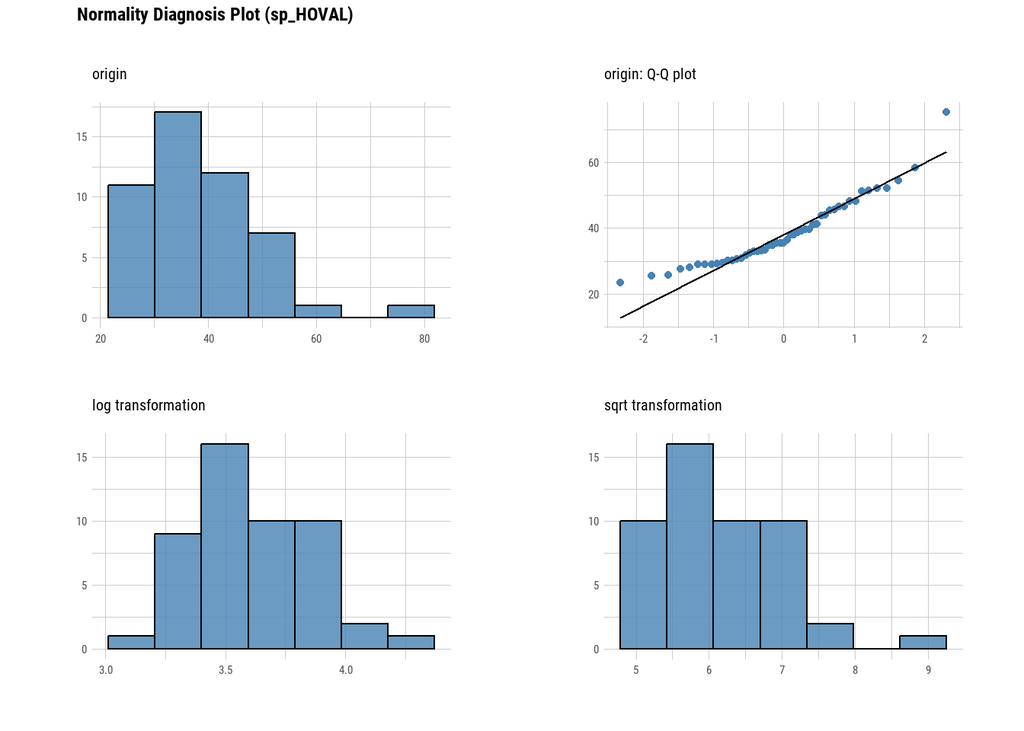

```r
plot_normality(columbus, sp_HOVAL)
```

- Como podemos ver en los histogramas la variable tiene una mejor distribución al hacer la transformación a log.

**Modelo no espacial con lag en la variable dependiente**

```r
modelo2_no_s <- lm(log(sp_HOVAL) ~ DISCBD + CRIME + log(INC) + AREA, data = columbus)

summary(modelo2_no_s)
```

```
##
## Call:
## lm(formula = log(sp_HOVAL) ~ DISCBD + CRIME + log(INC) + AREA,
##     data = columbus)
##
## Residuals:
##      Min       1Q   Median       3Q      Max
## -0.41999 -0.10719 -0.00726  0.10495  0.49633
##
## Coefficients:
##               Estimate Std. Error t value Pr(>|t|)
## (Intercept)  2.9626684  0.3351790   8.839 2.60e-11 ***
## DISCBD       0.1313647  0.0305579   4.299 9.37e-05 ***
## CRIME        0.0039928  0.0030254   1.320    0.194
## log(INC)     0.0563242  0.0984777   0.572    0.570
## AREA        -0.0007773  0.0073727  -0.105    0.917
## ---
## Signif. codes:  0 '***' 0.001 '**' 0.01 '*' 0.05 '.' 0.1 ' ' 1
##
## Residual standard error: 0.1983 on 44 degrees of freedom
## Multiple R-squared:  0.4086, Adjusted R-squared:  0.3549
## F-statistic:   7.6 on 4 and 44 DF,  p-value: 9.565e-05
```

VIF

```r
VIF(modelo2_no_s)
```

```
##   DISCBD    CRIME log(INC)     AREA
## 2.376053 3.129380 1.831095 1.310533
```

- Los resultados indican que no hay multicolinealidad.

**Lagrange Multiplier Diagnostic for Spatial Dependence (LMlag)**

```r
lm.LMtests(modelo2_no_s, rswm_qn, test = c("RLMlag"))
```

```
##
##  Lagrange multiplier diagnostics for spatial dependence
##
## data:
## model: lm(formula = log(sp_HOVAL) ~ DISCBD + CRIME + log(INC) + AREA,
## data = columbus)
## weights: rswm_qn
##
## RLMlag = 0.0068409, df = 1, p-value = 0.9341
```

- El p value es mayor a 5%

**Lagrange Multiplier Diagnostic for Spatial Error Dependence (LMerr)**

```r
lm.LMtests(modelo2_no_s, rswm_qn, test = c("RLMerr"))
```

```
##
##  Lagrange multiplier diagnostics for spatial dependence
##
## data:
## model: lm(formula = log(sp_HOVAL) ~ DISCBD + CRIME + log(INC) + AREA,
## data = columbus)
## weights: rswm_qn
##
## RLMerr = 0.6497, df = 1, p-value = 0.4202
```

**AIC**

```r
#Modelo original
AIC(modelo1_no_s)
```

```
## [1] 40.80974
```

```r
#Modelo LAG
AIC(modelo2_no_s)
```

```
## [1] -12.80212
```

- Podemos notar un gran cambio en el AIC comparando el modelo anterior con 40.8 y este modelo con -12.8, en base a esto podemos determinar que el modelo con spatial lag en la variable dependiente es mucho mejor que el modelo sin spatial lag.

## Modelo Global

**Spatial Durbin Model**

```r
spatial_durb <- lagsarlm(log(sp_HOVAL) ~  DISCBD + CRIME + log(INC) + AREA, data = columbus, rswm_qn, type = "mixed")
summary(spatial_durb)
```

```
##
## Call:lagsarlm(formula = log(sp_HOVAL) ~ DISCBD + CRIME + log(INC) +
##     AREA, data = columbus, listw = rswm_qn, type = "mixed")
##
## Residuals:
##         Min          1Q      Median          3Q         Max
## -0.32404083 -0.11549675 -0.00012347  0.09149856  0.41122903
##
## Type: mixed
## Coefficients: (asymptotic standard errors)
##                 Estimate  Std. Error z value Pr(>|z|)
## (Intercept)   1.59658279  0.79561689  2.0067  0.04478
## DISCBD        0.05921828  0.06613020  0.8955  0.37053
## CRIME         0.00342669  0.00241040  1.4216  0.15514
## log(INC)      0.00723135  0.08128923  0.0890  0.92912
## AREA          0.00094174  0.00617009  0.1526  0.87869
## lag.DISCBD   -0.06313781  0.08883258 -0.7108  0.47724
## lag.CRIME    -0.00835370  0.00587011 -1.4231  0.15471
## lag.log(INC) -0.00642501  0.16241988 -0.0396  0.96845
## lag.AREA      0.00938143  0.01084016  0.8654  0.38680
##
## Rho: 0.58997, LR test value: 12.045, p-value: 0.00051944
## Asymptotic standard error: 0.12793
##     z-value: 4.6118, p-value: 3.9921e-06
## Wald statistic: 21.269, p-value: 3.9921e-06
##
## Log likelihood: 19.50845 for mixed model
## ML residual variance (sigma squared): 0.023979, (sigma: 0.15485)
## Number of observations: 49
## Number of parameters estimated: 11
## AIC: -17.017, (AIC for lm: -6.9724)
## LM test for residual autocorrelation
## test value: 0.0018258, p-value: 0.96592
```

- En base al AIC Podemos determinar que este modelo es mejor que el modelo no espacial.

**Autocorrelación Espacial de los residuales estimados**

```r
moran.test(exp(spatial_durb$residuals), rswm_qn)
```

```
##
##  Moran I test under randomisation
##
## data:  exp(spatial_durb$residuals)
## weights: rswm_qn
##
## Moran I statistic standard deviate = 0.22394, p-value = 0.4114
## alternative hypothesis: greater
## sample estimates:
## Moran I statistic       Expectation          Variance
##     -0.0003556796     -0.0208333333      0.0083619638
```

```r
columbus_shp$spatial_durb_res <- exp(spatial_durb$residuals)
```

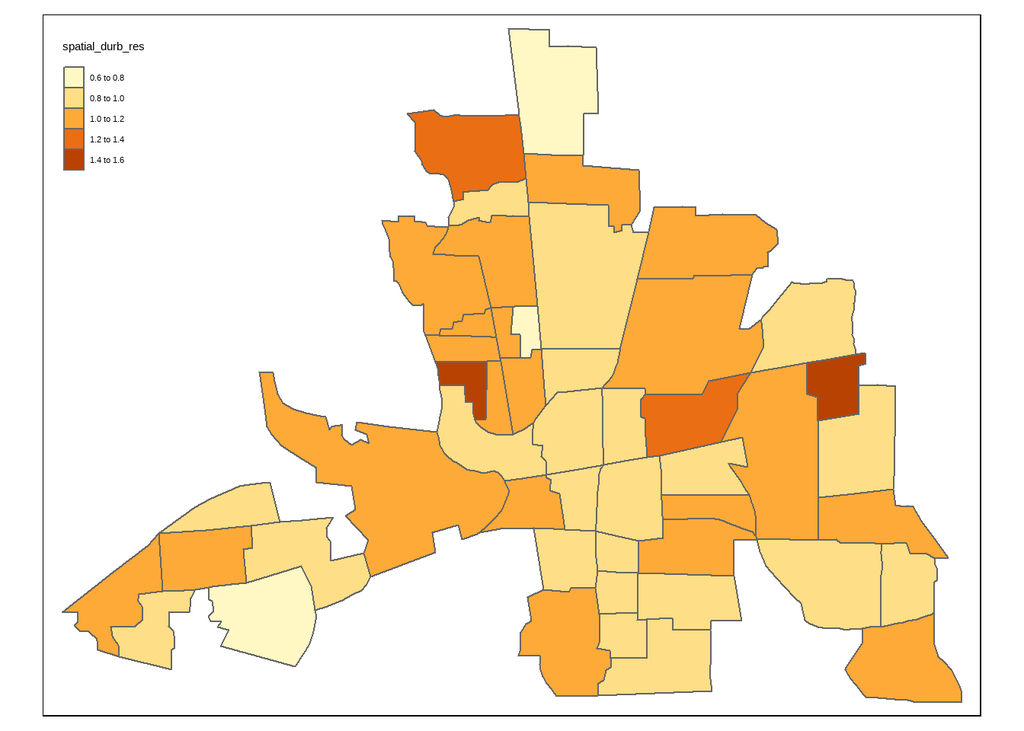

```r
qtm(columbus_shp,"spatial_durb_res" )
```

## Modelo Local

**Kernel bandwidth**

```r
kb1 <- bw.gwr(log(sp_HOVAL) ~  DISCBD + CRIME + log(INC) + AREA, approach = "AIC", adaptive = T, data = columbus_shp)
```

```
## Adaptive bandwidth (number of nearest neighbours): 37 AICc value: -13.01249
## Adaptive bandwidth (number of nearest neighbours): 31 AICc value: -8.045522
## Adaptive bandwidth (number of nearest neighbours): 42 AICc value: -13.51723
## Adaptive bandwidth (number of nearest neighbours): 44 AICc value: -12.99906
## Adaptive bandwidth (number of nearest neighbours): 39 AICc value: -13.53564
## Adaptive bandwidth (number of nearest neighbours): 39 AICc value: -13.53564
```

**Estimar Geographic Weighted Regression**

```r
loc_gwr <- gwr.basic(log(sp_HOVAL) ~  DISCBD + CRIME + log(INC) + AREA, adaptive = T, data = columbus_shp, bw = kb1)
```

```r
loc_gwr
```

```
##    *                       Package   GWmodel                             *
##    Program starts at: 2023-05-13 00:36:30
##    Call:
##    gwr.basic(formula = log(sp_HOVAL) ~ DISCBD + CRIME + log(INC) +
##     AREA, data = columbus_shp, bw = kb1, adaptive = T)
##
##    Dependent (y) variable:  sp_HOVAL
##    Independent variables:  DISCBD CRIME INC AREA
##    Number of data points: 49
##    *                    Results of Global Regression                     *
##
##    Call:
##     lm(formula = formula, data = data)
##
##    Residuals:
##      Min       1Q   Median       3Q      Max
## -0.42059 -0.10671 -0.00652  0.10321  0.49592
##
##    Coefficients:
##                 Estimate Std. Error t value Pr(>|t|)
##    (Intercept)  2.957965   0.326457   9.061 1.28e-11 ***
##    DISCBD       0.131521   0.030134   4.365 7.60e-05 ***
##    CRIME        0.004019   0.002879   1.396    0.170
##    log(INC)     0.058234   0.099986   0.582    0.563
##    AREA        -0.035104   0.239747  -0.146    0.884
##
##    ---Significance stars
##    Signif. codes:  0 '***' 0.001 '**' 0.01 '*' 0.05 '.' 0.1 ' ' 1
##    Residual standard error: 0.1982 on 44 degrees of freedom
##    Multiple R-squared: 0.4088
##    Adjusted R-squared: 0.355
##    F-statistic: 7.605 on 4 and 44 DF,  p-value: 9.519e-05
##    ***Extra Diagnostic information
##    Residual sum of squares: 1.729
##    Sigma(hat): 0.1918
##    AIC:  -12.81361
##    AICc:  -10.81361
##    BIC:  -27.11177
##    *          Results of Geographically Weighted Regression              *
##
```

[output cut: 10 more lines]

```
##    CRIME     -0.00752674 -0.00051285  0.00142795  0.00420988 0.0075
##    log(INC)  -0.36051466 -0.04399181  0.05195395  0.23604256 0.2654
##    AREA      -0.75165394 -0.37419456 -0.04859917  0.09815296 0.3890
##    ************************Diagnostic information*************************
##    Number of data points: 49
##    Effective number of parameters (2trace(S) - trace(S'S)): 15.17891
##    Effective degrees of freedom (n-2trace(S) + trace(S'S)): 33.82109
##    AICc (GWR book, Fotheringham, et al. 2002, p. 61, eq 2.33): -13.53564
##    AIC (GWR book, Fotheringham, et al. 2002,GWR p. 96, eq. 4.22): -39.39323
##    BIC (GWR book, Fotheringham, et al. 2002,GWR p. 61, eq. 2.34): -52.23591
##    Residual sum of squares: 0.9948435
##    R-square value:  0.6598045
##    Adjusted R-square value:  0.5024728
##
##    Program stops at: 2023-05-13 00:36:30
```

- En base a los resultados podemos concluir que la variable que explicativa que tiene un mayor efecto en la variable dependiente es DISCBD.
- En base al AICc y AIC podemos concluir que es te es un buen modelo para explicar el costo de las casas en Columbus.

**Interpretación de la variable explicativa más significativa en base al p-value.**

- Por cada unidad de incremento en DISCBD habra un aumento de 0.131521 en HOVAL
- DISCBD tiene un p-value de 7.60e-05 por lo cual se puede concluir que es significativa.

**Mapeo de resultados de GWR**

```r
gwr_sf <- st_as_sf(loc_gwr$SDF)
gwr_sf
```

```
## Simple feature collection with 49 features and 21 fields
## Geometry type: POLYGON
## Dimension:     XY
## Bounding box:  xmin: 5.874907 ymin: 10.78863 xmax: 11.28742 ymax: 14.74245
## CRS:           NA
## First 10 features:
##   Intercept     DISCBD         CRIME   log(INC)       AREA        y     yhat
## 0  3.004007 0.05791119 -0.0009324707  0.2383766 -0.5509936 3.568363 3.818592
## 1  3.047234 0.03961611 -0.0013043500  0.2360426 -0.4512176 3.843152 3.796087
## 2  2.956053 0.07087822 -0.0007322015  0.2426707 -0.5630264 3.814735 3.773138
## 3  3.024444 0.04408682 -0.0013030647  0.2408232 -0.4509552 3.490939 3.468537
## 4  2.905689 0.08341224 -0.0004885745  0.2435359 -0.5152399 3.378121 3.454554
## 5  2.804498 0.13254807  0.0005148758  0.2410408 -0.7516539 3.635281 3.774917
## 6  3.024061 0.04428500 -0.0007711186  0.2226175 -0.3388243 3.566888 3.532944
## 7  2.998060 0.04784869 -0.0012672539  0.2457828 -0.4310780 3.568241 3.596074
```

[output cut: 35 more lines]

```r
gwr_sf$y_predicted <- exp(gwr_sf$yhat)
```

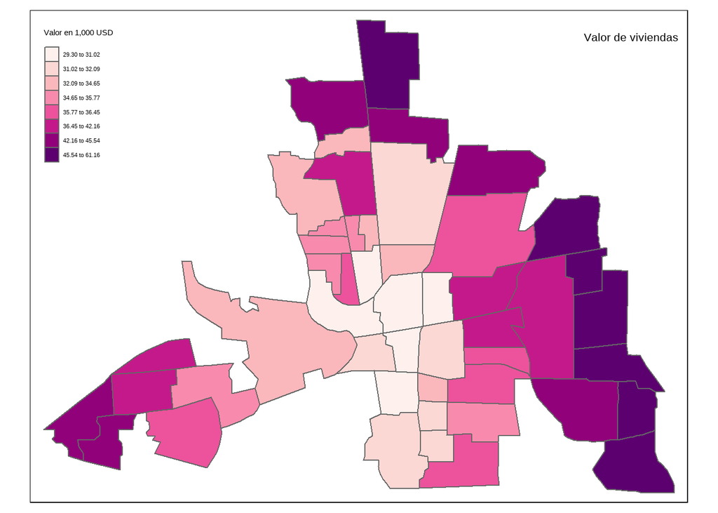

```r
tm_shape(gwr_sf) +
  tm_polygons(col = "y_predicted", palette = "RdPu", style = "quantile", n=8, title = "Valor en 1,000 USD") +
  tm_layout(title = 'Valor de viviendas', title.position = c('right', 'top'))
```

**Visualización de la predicción local de variables explicativas estadísticamente significativas**

Distancia a Business District

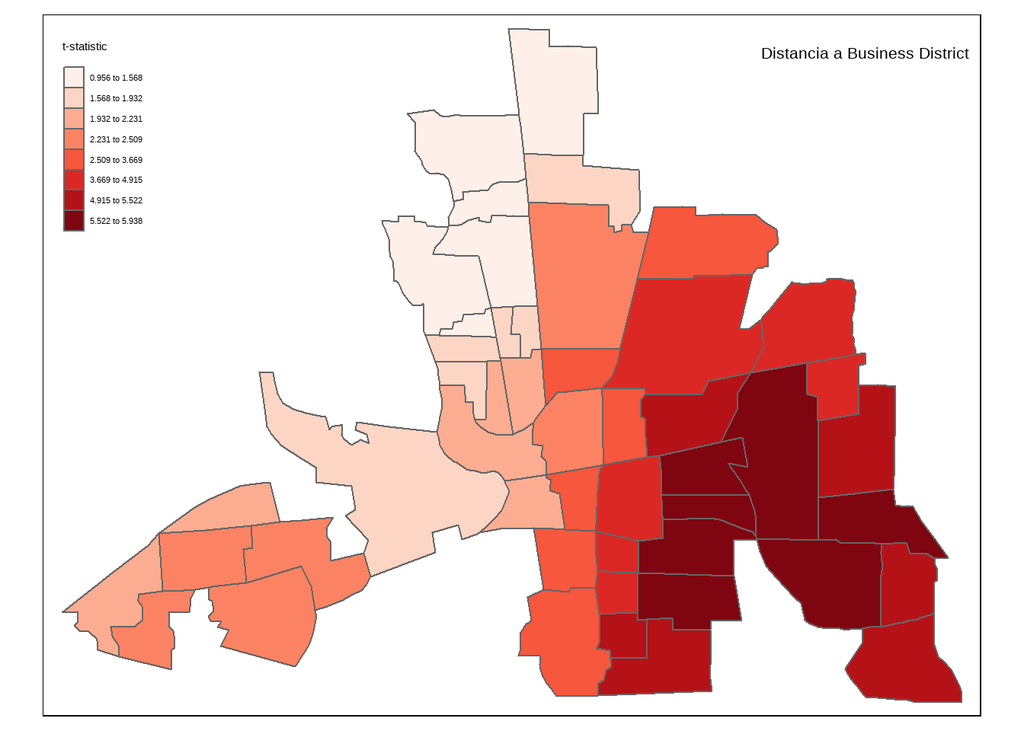

```r
tm_shape(gwr_sf) +
  tm_polygons(col = "DISCBD_TV", palette = "Reds", style = "quantile" , n=8, title= "t-statistic") +
  tm_layout(title = 'Distancia a Business District', title.position = c('right', 'top'))
```

Taza de Criminalidad

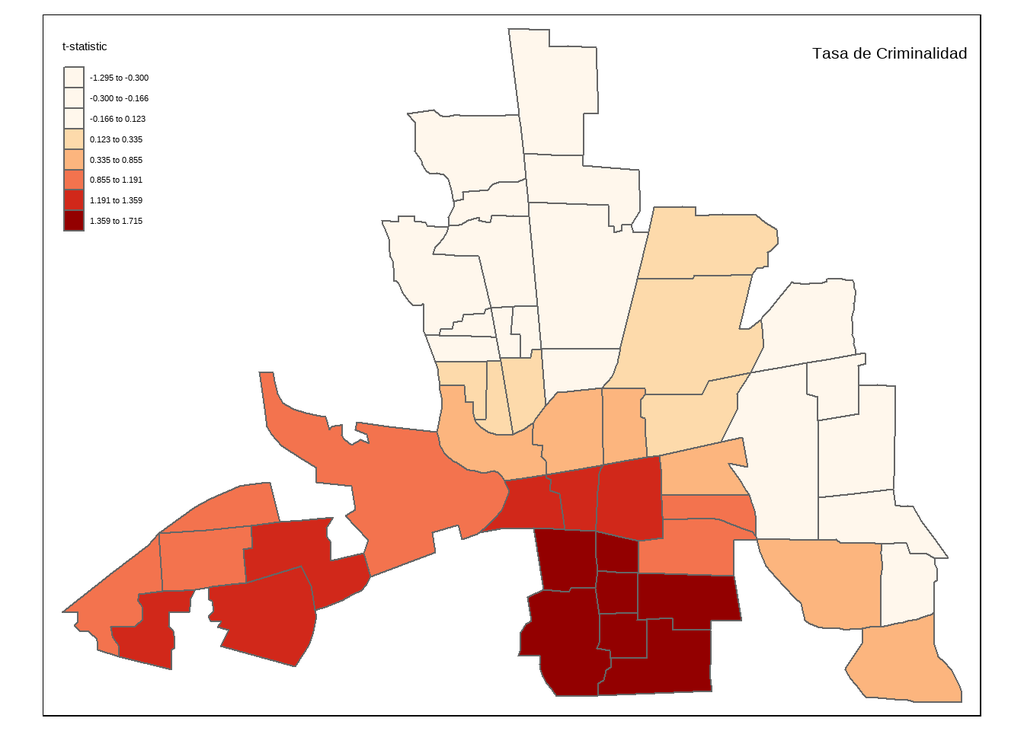

```r
tm_shape(gwr_sf) +
  tm_polygons(col = "CRIME_TV", palette = "OrRd", style = "quantile" , n=8, title= "t-statistic") +
  tm_layout(title = 'Tasa de Criminalidad', title.position = c('right', 'top'))
```

R2

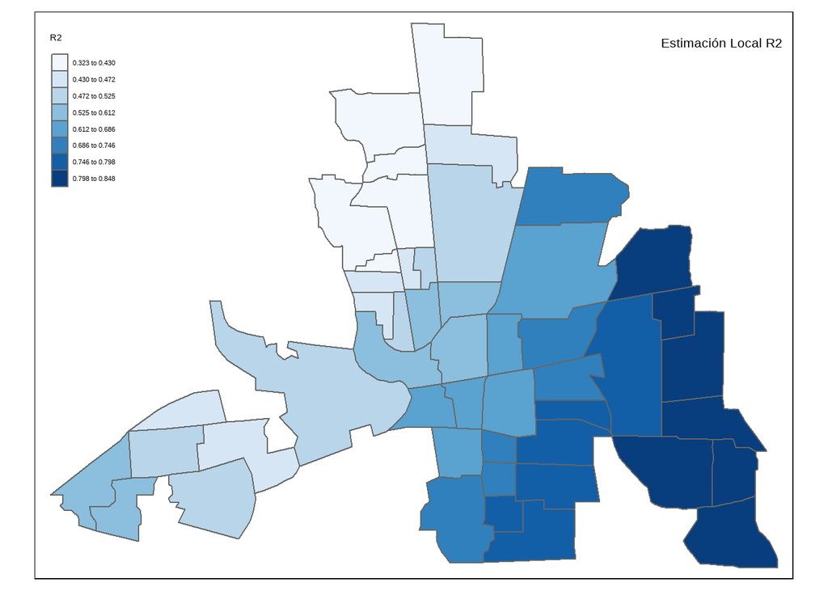

```r
tm_shape(gwr_sf) +
  tm_polygons(col = "Local_R2", palette = "Blues", style = "quantile" , n=8, title= "R2") +
  tm_layout(title = 'Estimación Local R2', title.position = c('right', 'top'))
```

Regression Residuals

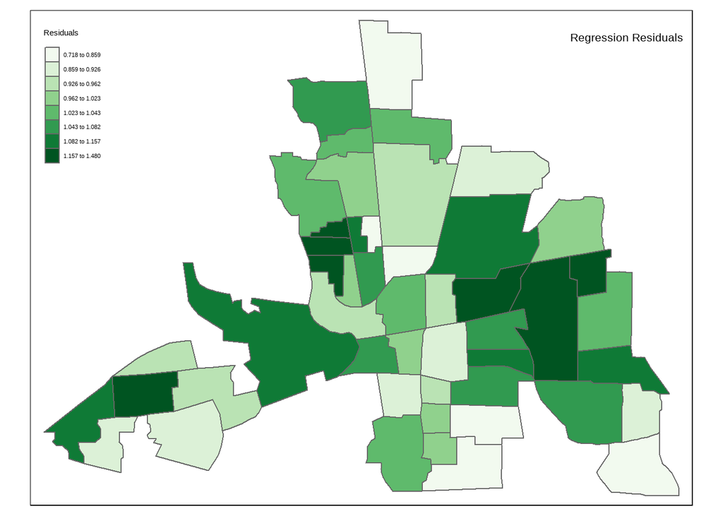

```r
gwr_sf$exp_res <- exp(gwr_sf$residual)
tm_shape(gwr_sf) +
   tm_polygons(col = "exp_res", palette="Greens", style="quantile", n=8, title="Residuals") +
  tm_layout(title= 'Regression Residuals',  title.position = c('right', 'top'))
```

**Autocorrelación Espacial de los residuales estimados**

```r
moran.test(gwr_sf$exp_res, rswm_qn)
```

```
##
##  Moran I test under randomisation
##
## data:  gwr_sf$exp_res
## weights: rswm_qn
##
## Moran I statistic standard deviate = 1.4766, p-value = 0.06989
## alternative hypothesis: greater
## sample estimates:
## Moran I statistic       Expectation          Variance
##       0.113772429      -0.020833333       0.008310139
```

# Selección de Modelo

## Selección de modelo

En base al AIC llegue a la conclusión que el mejor modelo para determinar el precio de las casas en Columbus es el modelo de Regresión espacial local con un AIC de -39.4 en comparación a -17.017 en el modelo global y -12.80212 en el modelo no espacial.

## Visualización de HOVA

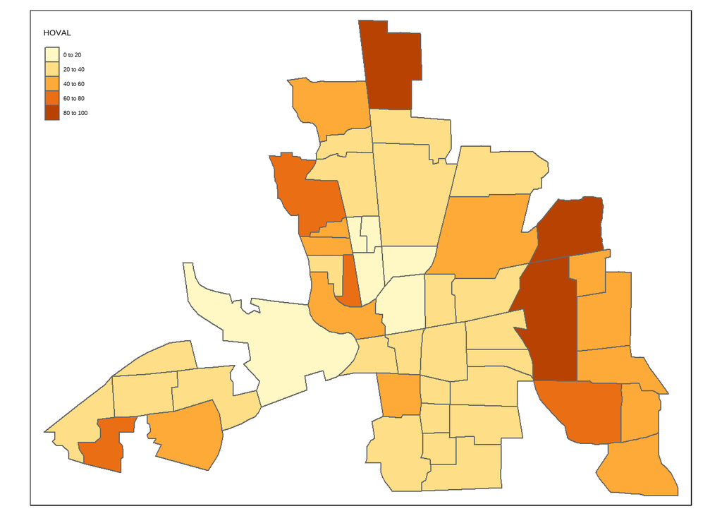

```r
qtm(columbus_shp, "HOVAL")
```

- Se observa una concentración de valores altos al este y norte de Columbus.

# Random Forest

coordinates

```r
coordss <- coordinates(columbus_shp)
head(coordss)
```

```
##       [,1]     [,2]
## 0 8.827218 14.36908
## 1 8.332658 14.03162
## 2 9.012265 13.81972
## 3 8.460801 13.71696
## 4 9.007982 13.29637
## 5 9.739926 13.47463
```

Data para el Random Forest

```r
rf_dat <- columbus %>% select(AREA, INC, CRIME, DISCBD, sp_HOVAL)

rf_dat <- rf_dat %>% mutate(across(c(sp_HOVAL, INC), function(x) log(x)))

formula_rf <- "sp_HOVAL ~ DISCBD + CRIME + INC + AREA"
```

**Optimal Bandwidth Selection**

Lo decidí hacer con un mínimo de 37 y máximo de 42 porque entre esos intervalos se encontraba el AIC más bajo del Kernel bandwidth

```r
bwgrf <- grf.bw(formula = formula_rf, dataset = rf_dat, kernel = "adaptive", coords = coordss, bw.min = 37, bw.max = 42, step = 1, trees = 500, mtry = NULL, importance = "impurity", forests = FALSE, weighted = TRUE, verbose = TRUE)
```

```
## Bandwidth: 37
```

```
## R2 of Local Model: 0.205213625103152
```

```
## Bandwidth: 38
```

```
## R2 of Local Model: 0.204831528519056
```

```
## Bandwidth: 39
```

```
## R2 of Local Model: 0.21517916847563
```

```
## Bandwidth: 40
```

```
## R2 of Local Model: 0.212283842745192
```

```
## Bandwidth: 41
```

```
## R2 of Local Model: 0.192391341963029
```

```
## Bandwidth: 42
```

```
## R2 of Local Model: 0.192600252539304
```

```
## Best Bandwidth (Based on the Local Model): 39
```

**GRF Estimation**

```r
grf_model <- grf(formula = formula_rf, dframe = rf_dat, bw = bwgrf$Best.BW, ntree = 500, mtry = 2, kernel = "adaptive", forests = TRUE, coords = coordss)
```

```
##
## Number of Observations: 49
```

```
## Number of Independent Variables: 4
```

```
## Kernel: Adaptive
## Neightbours: 39
```

```
##
## --------------- Global Model Summary ---------------
```

```
## Ranger result
##
## Call:
##  ranger(formula_rf, data = rf_dat, num.trees = 500, mtry = 2,      importance = "impurity", num.threads = NULL)
##
## Type:                             Regression
## Number of trees:                  500
## Sample size:                      49
## Number of independent variables:  4
## Mtry:                             2
## Target node size:                 5
## Variable importance mode:         impurity
## Splitrule:                        variance
## OOB prediction error (MSE):       0.04747162
## R squared (OOB):                  0.2207997
```

```
##
## Importance:
```

```
##    DISCBD     CRIME       INC      AREA
## 1.1978931 0.4870933 0.5620217 0.4179139
```

```
##
## Mean Square Error (Not OBB): 0.009
```

```
## R-squared (Not OBB) %: 84.211
```

```
## AIC (Not OBB): -218.567
```

```
## AICc (Not OBB): -217.171
```

```
##
## --------------- Local Model Summary ---------------
```

```
##
## Residuals OOB:
```

```
##     Min.  1st Qu.   Median     Mean  3rd Qu.     Max.
## -0.55667 -0.11630  0.03157  0.01131  0.14820  0.66380
```

```
##
## Residuals Predicted (Not OBB):
```

```
##       Min.    1st Qu.     Median       Mean    3rd Qu.       Max.
## -0.0909200 -0.0150306  0.0001396 -0.0014477  0.0171505  0.0650780
```

```
##
## Local Variable Importance:
```

```
##              Min       Max      Mean        StD
## DISCBD 0.2995852 1.5901250 0.7205589 0.42539293
## CRIME  0.1683378 0.8473273 0.3717427 0.17635704
## INC    0.2524345 0.7063297 0.4611670 0.11465744
## AREA   0.2201529 0.4300722 0.3247466 0.05528003
```

```
##
## Mean squared error (OOB): 0.053
```

```
## R-squared (OOB) %: 10.452
```

```
## AIC (OBB): -133.529
```

```
## AICc (OBB): -132.133
```

```
## Mean squared error Predicted (Not OBB): 0.001
```

```
## R-squared Predicted (Not OBB) %: 98.322
```

```
## AIC Predicted (Not OBB): -328.396
```

```
## AICc Predicted (Not OBB): -327
```

```
##
## Calculation time (in seconds): 0.9108
```

- En base al AIC este es el mejor modelo de predicción para los precios de las casas en Columbus.

**Visualización de resultados estimados de GRF**

Variable dependiente

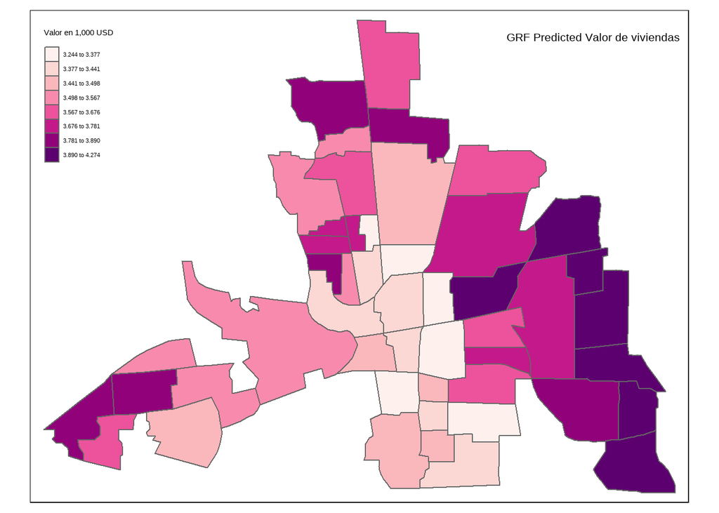

```r
columbus_shp$grf_predicteddv <- grf_model$LGofFit$LM_yfitPred
tm_shape(columbus_shp) +
  tm_polygons(col = "grf_predicteddv", palette="RdPu", style="quantile", n=8, title="Valor en 1,000 USD") +
  tm_layout(title= 'GRF Predicted Valor de viviendas',  title.position = c('right', 'top'))
```

local R2

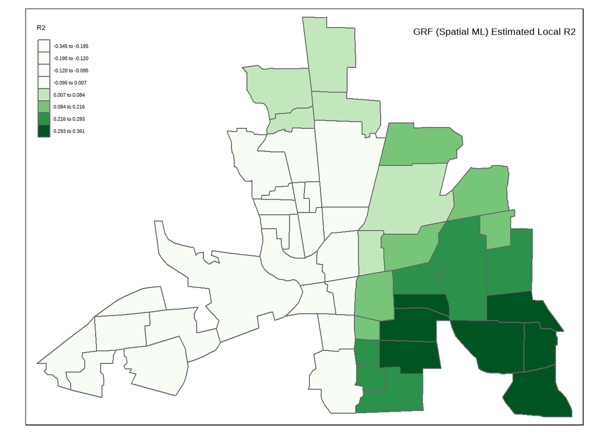

```r
columbus_shp$grf_localR2 <- grf_model$LGofFit$LM_Rsq100
tm_shape(columbus_shp) +
   tm_polygons(col = "grf_localR2", palette="Greens", style="quantile", n=8, title="R2") +
  tm_layout(title= 'GRF (Spatial ML) Estimated Local R2',  title.position = c('right', 'top'))
```

- Podemos observar clusters en este mapa teniendo una concentracion de datos altos al sureste de Columbus y una concentración de datos bajos en toda la sona oeste.